# FW472 Learning Activity 3

Spring 2024

## Learning Objectives

- Continue working with geospatial data plotting
- Access a new data source through an API [GBIF](https://www.gbif.org/what-is-gbif)
- Use information from the [USGS Nonindigenous Aquatic Species (NAS)](https://nas.er.usgs.gov/about/default.aspx)
- Become acquainted with three different ways to visualize species occurrence data
- Map the origin and invasion through time of an NAS

Install required packages:

```r
library(rgbif) #Package for accessing GBIF API
library(ggplot2) #Plotting library
library(maps) #Basemap library
library(hexbin) #Hexbin for plotting
library(ggthemes) #Themes for plotting
library(gganimate) #Animation library for ggplot
library(gifski) #GIF-making library
```

## GBIF API Data Pull

We will use the [occ_data()](https://rdrr.io/cran/rgbif/man/occ_data.html) function from the package rgbif to access the GBIF API for data. You can see the many toggles available to us for pulling data and that they are unique to this API, just as with the USGS API we used in the last exercise.

Here, we will specify we want data for the **scientificName** of *Hyla versicolor*, or the gray treefrog. For this example pull, I will also specify **stateProvince** of Michigan and, importantly, specify **hasCoordinate = TRUE** since we only want occurrence records that have coordinates that we can map.

Since we get much more information than we need, we also have to do some cleaning of the data pull to get something simpler to work with. First, we want to (1) take the data portion of the pull and turn it into a dataframes, (2) remove occurrence records without year reported, and (3) specify what columns we want to keep out of the 100+.

**IMPORTANTLY**, we then save the data using **write.csv()** so that we have a local file for these data. We then don’t have to pull data again from the API which can be time consuming and so that our data do not change. After writing this once, we can # out the API pull code so that it won’t run each time we generate our report.

```r
#hyla_data <- occ_data(scientificName = c("Hyla versicolor"), stateProvince = "Michigan", hasCoordinate = TRUE, limit = 20000)

#hyla_data <- as.data.frame(hyla_data$data)

#hyla_data <- hyla_data[!is.na(hyla_data$year), ]

#columns_to_keep <- c("key", "scientificName", "decimalLatitude", "decimalLongitude", "occurrenceStatus", "basisOfRecord", "gbifRegion", "stateProvince", "year", "datasetName")

#hyla_data <- hyla_data[, columns_to_keep]

#write.csv(hyla_data, file = "hyla_data.csv")
```

Next we can read back in our saved data to work with:

```r
hyla_data <- read.csv(file = "hyla_data.csv")
```

## Creating basemaps

The packages we brought in above contain basemaps that we can use to plot our species occurrence data on top of. Here, we are saying we want a US county map that I have centered around Michigan with the x limit for our longitude range and y limit for our latitude range around the state. We also specify the colors we want for our map.

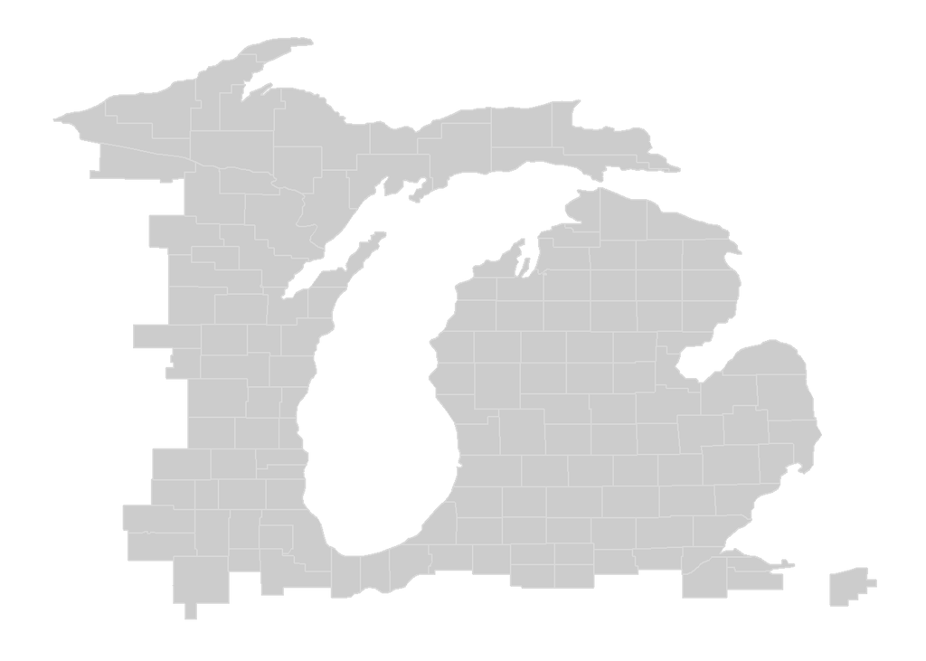

```r
michigan <- ggplot() +
  borders("county", colour = "gray85", fill = "gray80", xlim = c(-89, -82), ylim = c(41.5, 48)) +
  theme_map()
michigan
```

We can also create world and U.S. basemaps in the same way. You can use these basemaps for your portion of the exercise.

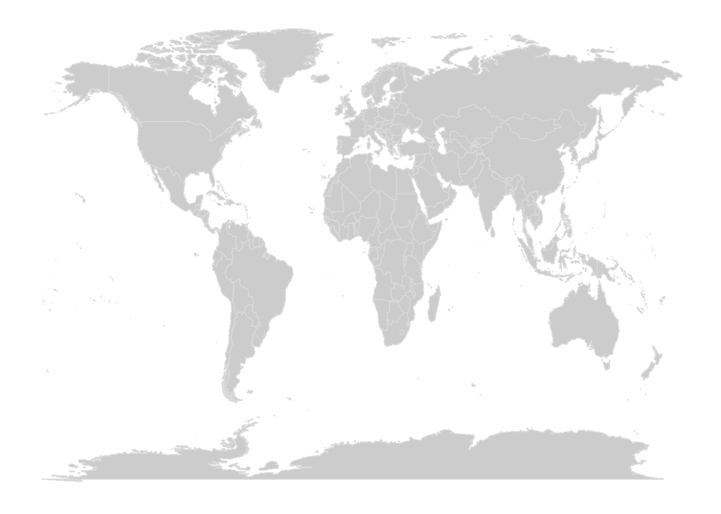

```r
world <- ggplot() +
  borders("world", colour = "gray85", fill = "gray80") +
  theme_map()
world
```

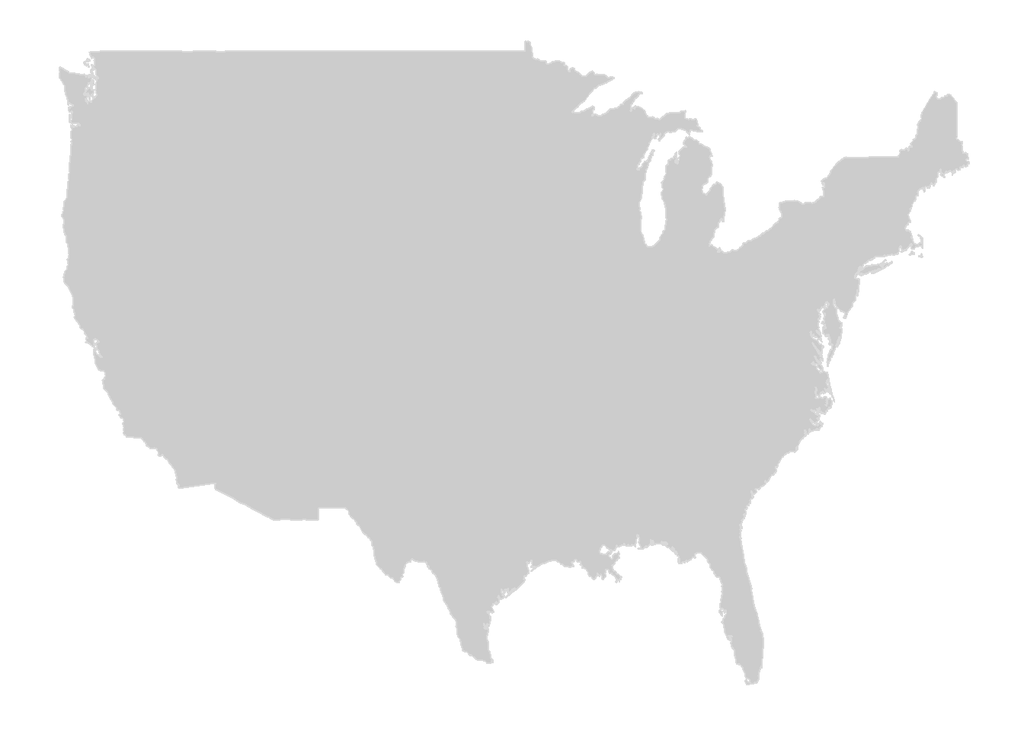

```r
usa <- ggplot() +
  borders("usa", colour = "gray85", fill = "gray80") +
  theme_map()
usa
```

## Plotting Occurrence Data

We can now plot our point data (a **vector** type) for the occurrence of *Hyla versicolor* in GBIF across Michigan. Just as we used ‘+’ to layer maps in the previous exercise, we can layer points using **geom_point()** on top of our basemap, specifying the data source **hyla_data** and that our **aes()** or aesthetic uses the column **decimalLongitude** for the x data and the column **decimalLatitude** for the y data. We can also specify the size of our points using **size =** .

We can layer on still more commands by specifying the title we want and the text size of that title.

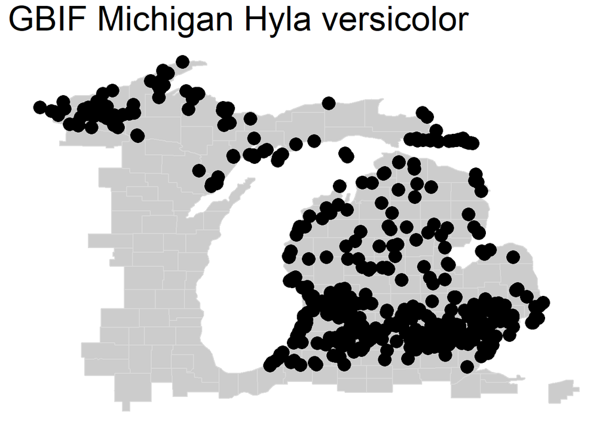

```r
michigan +
    geom_point(data = hyla_data, aes(decimalLongitude, decimalLatitude), size = 5) +
    labs(title = 'GBIF Michigan Hyla versicolor') +
  theme(plot.title = element_text(size=28))
```

Although our data here are accurate, you can see a common issue with mapping where you have many overlapping points that make it difficult to see the actual density of the data. We call this overplotting. Next, we will go over three (of many) strategies to better visualize overlapping data.

### 2D Density Plot

One is to bin the data and instead plot the density as opposed to each individual point. Here, we do this with **geom_bin2d()**. Note that here instead of point size we specify the number of **bins =** . If you increase the number of bins, then you will get smaller bins and vice versa. If you use this method then you can adjust the bin size for one that makes sense for your occurrence data for visualization.

We also specify the color ramp, again using the color-blind friendly palette viridis.

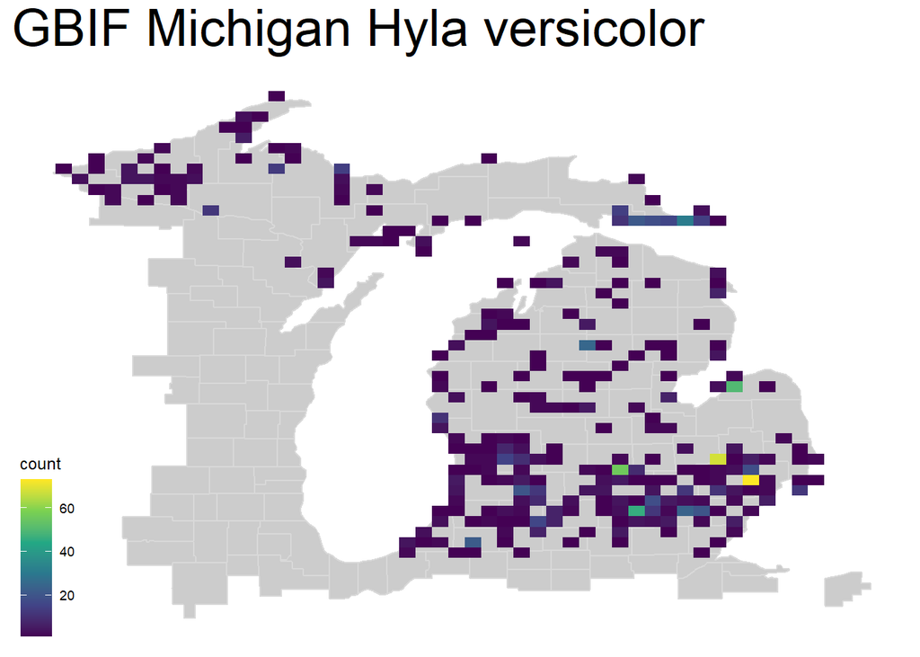

```r
michigan +
    geom_bin2d(data = hyla_data, aes(decimalLongitude, decimalLatitude), bins = 50) +
  scale_fill_continuous(type = "viridis") +
    labs(title = 'GBIF Michigan Hyla versicolor') +
  theme(plot.title = element_text(size=28))
```

### Hexbin Plot

A nearly identical method that many prefer visually is the hexbin plot, here using **geom_hex()**. For this, we will set a smaller number of bins to show how decreasing this number leads to larger areas to calculate point density.

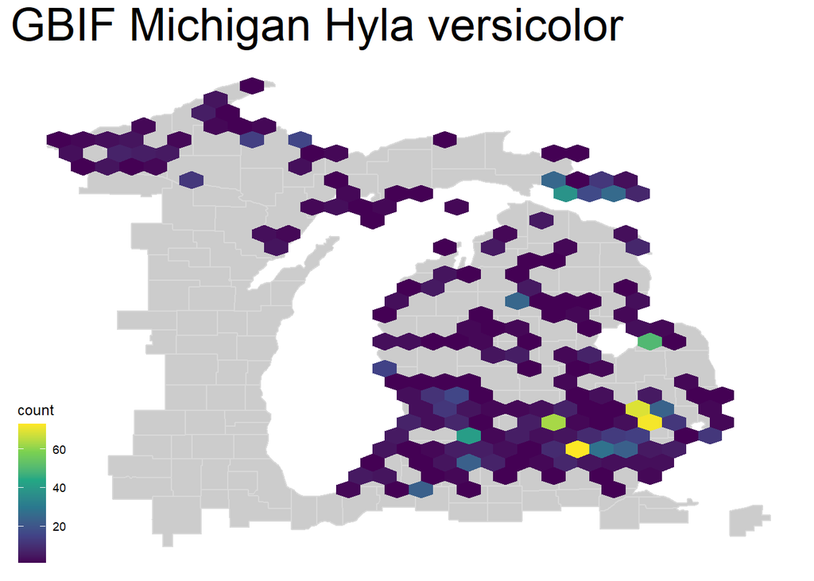

```r
michigan +
    geom_hex(data = hyla_data, aes(decimalLongitude, decimalLatitude), bins = 30) +
  scale_fill_continuous(type = "viridis") +
    labs(title = 'GBIF Michigan Hyla versicolor') +
  theme(plot.title = element_text(size=28))
```

### Animated Occurrence Plot

Finally, we can also plot occurrences through times using an animation. **NOTE:** Making an animation will be optional here but can be a useful skill to learn if you are up for a challenge. You can actually animate nearly any kind of plot, not just maps!

We will again use **geom_point()** for plotting points, but we will change the **alpha =** to a value below 1, which decreases point opacity.

We specify that we want transitions between frames, **transition_reveal()** of our animation to be based on year observed. We also specify that each point is unique by specifying **group =** the unique identifier named **key** in our data. Finally, we indicate that we want the title for each frame of our animation to be our year. This whole object called **ani_hyla** is our set of frames that we want to animate.

Next, we use the **animate()** function to animate our above plot, specifying the pixel height and pixel width of the animation. You may need to change these proportions depending on what makes sense for your map. Finally, we specify that we want to render it as a gif using the **gifski_renderer()**.

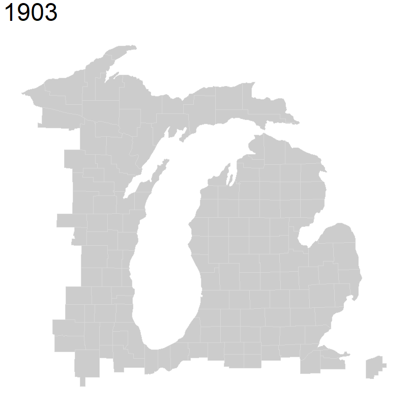

```r
ani_hyla <- michigan +
  geom_point(data = hyla_data,
             aes(decimalLongitude, decimalLatitude, group = key), color = 'dark green', size = 5, alpha = 0.4) +
  transition_reveal(year) +
  labs(title = '{(frame_along)}') +
  theme(plot.title = element_text(size=48))

animate(ani_hyla, height = 800, width = 800, renderer = gifski_renderer())
```

## Exercise Questions (40 pts)

First, choose one of following non-native invasive species to the Great Lakes region:

1. [Proterorhinus semilunaris](https://nas.er.usgs.gov/queries/factsheet.aspx?SpeciesID=714) **Tubenose goby**
2. [Nitellopsis obtusa](https://nas.er.usgs.gov/queries/FactSheet.aspx?SpeciesID=1688) **Starry stonewort**
3. [Bythotrephes longimanus](https://nas.er.usgs.gov/queries/factsheet.aspx?SpeciesID=162) **Spiny waterflea**

You may also select a different species from the USGS NAS based on HUC 04 - Great Lakes if you are interested in a different one. However, some species may have too few records to make nice plots or so many records that your API call may take a long time.

Based on the USGS NAS:

**1.1 What year was your species first observed in the U.S. (3 pts):**

**1.2 What was the means of introduction for the species into the U.S. (3 pts):**

### GBIF API Call (10 pts)

Bring in your chosen species occurrence data from the GBIF API using the **occ_data** function **5 pts*. Specify that the records have coordinates and are for all records, i.e. you do not need to specify a state or country. This may take a few minutes to bring into your session, which is another reason why we want to only do this once! Spiny waterflea has the smallest data set.

Clean data as in the tutorial by converting to a data frame, removing NA for year, and selecting the same columns as above **2 pts**

Save your data locally using **write.csv()** and # out your code once you have your local data so that it doesn’t run again **3 pts**

### Pre-Invasion Distribution (10 pts)

Make a map of the pre-invasion distribution of your species based on GBIF data by filtering the data frame to the years **before** introduction from question 1.1. **Hint:** You will likely want to filter using ‘<’ for the year column of your data and use the world basemap above. **8 pts**

You may optionally zoom in on the world map to better visualize the range.

**2. Describe the pre-invasion distribution of your chosen species (1 sentence; 2 pts):**

### U.S. Invasion Through Time (14 pts)

Create a plot or plots that show the spread of your chosen invasive species through time for the U.S. using a visualization method that deals with overplotting **Hint:** You can filter your data to gbifRegion == “NORTH_AMERICA” and use the usa basemap above.

You may either create a set of at least 3 plots that show cumulative occurrence through time **-OR-** you can create one animated map as above. If you create multiple static maps, you will want to do a map for a couple years after invasion, a midpoint year, and then all occurrences up through the present.

**3.1 Describe the range expansion of your chosen species through time. Does expansion appear to be accelerating? (1 sentence; 2 pts):**

**3.2 What was the most common data source for your chosen species US occurrence data? (2 pts):**